# FigureYa288MutualExclusivity

**Author(s)**: Xiaofan Lu; Yasi Zhang  
**Reviewer(s)**: Ying Ge  
**Date**: 2025-05-20

# 需求描述

# Requirements Description

瀑布图，重点是基因之间突变相关性pvalue。

Waterfall plot focusing on mutation correlation p-values between genes.

两个基因之间:

Between two genes:

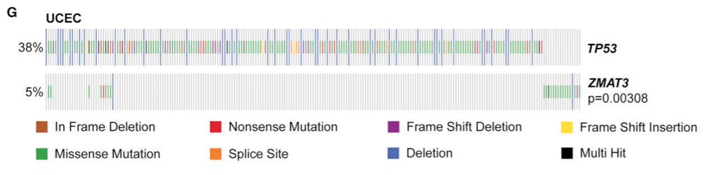

出自https://linkinghub.elsevier.com/retrieve/pii/S1097276520307292

图5. ZMAT3具有p53依赖性与非依赖性双重功能 (G) 在子宫体子宫内膜癌(UCEC)中，ZMAT3突变与TP53突变呈现互斥模式。P值来源于DISCOVER互斥性检验。

Source: https://linkinghub.elsevier.com/retrieve/pii/S1097276520307292

Figure 5. ZMAT3 Has p53-Dependent and -Independent Activities (G) Mutations in ZMAT3 are mutually exclusive with TP53 mutations in UCEC. p value, DISCOVER mutual exclusivity test.

多个基因之间：

Among multiple genes:

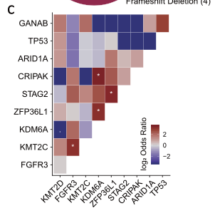

出自https://genomebiology.biomedcentral.com/articles/10.1186/s13059-020-02230-w

图1. 通过全外显子组测序分析的30例上尿路尿路上皮癌(UTUC)体细胞突变图谱，包括15例肌层浸润性肿瘤和15例非肌层浸润性肿瘤。 c图展示UTUC全队列中具有互斥或共现模式的基因热图。星号标注具有统计学显著性的相关性。

Source: https://genomebiology.biomedcentral.com/articles/10.1186/s13059-020-02230-w

Fig. 1 Genetic landscape of somatic mutations identified by whole-exome sequencing of 30 upper tract urothelial carcinomas (UTUC), including 15 muscle-invasive tumors and 15 non-muscle-invasive tumors. c Heatmap for genes with mutual exclusivity or co-occurrence in the whole UTUC cohort. Stars refer to correlations that are statistically significant.

# 应用场景

# Application Scenarios

Mutual-exclusivity analysis，我们众筹过FigureYa70mutationEventshttps://k.youshop10.com/5qGbYAM3，用Discover包实现TCGA的基因突变数据分析Co-occurrence/mutual exclusivity，未计算Odds Ratio。

这次我们用单侧Fisher’s exact检验，并计算**Odds Ratio和P值**。

从费谢尔检验的代码来看，“less” 表示mutual-exclusivity analysis（二者“竞争”出现；OR<1）, 而”greater”则代表co-occurrence analysis（二者“共生”出现; OR>1）

For mutual exclusivity analysis, our previous crowdsourced project FigureYa70mutationEventshttps://k.youshop10.com/5qGbYAM3 implemented the DISCOVER package to analyze TCGA gene mutation patterns (co-occurrence/mutual exclusivity) without calculating odds ratios.

In this analysis, we employ one-sided Fisher’s exact test to compute both **Odds Ratios (OR) and P values**.

As demonstrated in the Fisher’s test implementation: “less” alternative indicates mutual exclusivity (competitive pattern; OR < 1), “greater” alternative denotes co-occurrence (cooperative pattern; OR > 1)

# 环境设置

# Environment Setup

使用国内镜像安装包。

Using domestic mirrors for package installation.

```r
options("repos"= c(CRAN="https://mirrors.tuna.tsinghua.edu.cn/CRAN/"))
options(BioC_mirror="http://mirrors.tuna.tsinghua.edu.cn/bioconductor/")
```

# 加载包

# Loading packages

```r
library(ggplot2)
library(dplyr)
library(tidyverse)
library(readr)
library(maftools)

# 显示英文报错信息
# Show English error messages
Sys.setenv(LANGUAGE = "en")

# 禁止chr转成factor
# Prevent character-to-factor conversion
options(stringsAsFactors = FALSE)
```

# 第一种情况：一两个基因的作用

# Case 1: Interaction between two genes

按照原文所示，当考虑两个基因的作用时，计算mutual exclusivity并绘制热图：

As shown in the paper, when analyzing two genes, calculate mutual exclusivity and plot heatmap.

## 输入文件

## Input Files

easy_input_two_genes.txt，突变的MAF文件。这里文件事先处理了，只保存了原文的两个基因。

The input file “easy_input_two_genes.txt” is a pre-processed MAF (Mutation Annotation Format) file containing only the two target genes from the original publication.

```r
maf <- read_tsv("easy_input_two_genes.txt", comment = "#")
# 定义需要保留的列
# Define columns to keep
label <- c("Tumor_Sample_Barcode",
           "Hugo_Symbol",
           "Chromosome",
           "Start_Position",
           "End_Position",
           "Variant_Classification",
           "Variant_Type",
           "Reference_Allele",
           "Tumor_Seq_Allele1",
           "Tumor_Seq_Allele2")

# 保存一些可能会用到的列
# Keep potentially useful columns
maf <- maf[,label]
```

## 计算突变二值矩阵（1为突变型，0为野生型）

## Create binary mutation matrix (1=mutated, 0=wildtype)

```r
mut.binary <- matrix(0,nrow = length(unique(maf$Hugo_Symbol)),ncol = length(unique(maf$Tumor_Sample_Barcode)),dimnames = list(unique(maf$Hugo_Symbol),unique(maf$Tumor_Sample_Barcode)))
for (i in colnames(mut.binary)) {
  tmp <- maf[which(maf$Tumor_Sample_Barcode == i),]

  # 仅考虑如下非同义突变
  # Consider only these non-synonymous mutations
  tmp <- tmp[which(tmp$Variant_Classification %in% c("Frame_Shift_Del", "Frame_Shift_Ins", "Splice_Site", "Translation_Start_Site","Nonsense_Mutation", "Nonstop_Mutation", "In_Frame_Del","In_Frame_Ins", "Missense_Mutation")),]
  for (j in tmp$Hugo_Symbol)
    mut.binary[j,i] <- 1
}
mut.binary <- as.data.frame(mut.binary)#; rownames(mut.binary) <- toupper(rownames(mut.binary))

write.table(mut.binary,"binary_mutation_matrix_two_genes.txt",sep = "\t",row.names = T,col.names = NA,quote = F)
```

## 计算mutual exclusivity

## Calculate mutual exclusivity

```r
tmp <- as.data.frame(t(mut.binary))
print(fisher.test(table(tmp$TP53,tmp$ZMAT3)))
```

```
##
##  Fisher's Exact Test for Count Data
##
## data:  table(tmp$TP53, tmp$ZMAT3)
## p-value = 2.391e-11
## alternative hypothesis: true odds ratio is not equal to 1
## 95 percent confidence interval:
##  0.006975319 0.086925243
## sample estimates:
## odds ratio
## 0.02604153
```

可以看到此时OR是小于1的，所以为“竞争”关系，采用单侧检验计算，可以看到置信区间发生了一些改变（大多数情况P值也会改变）。

The observed odds ratio (OR) being less than 1 indicates a “mutually exclusive” relationship (competitive pattern), prompting the use of a one-sided test. Note this approach modifies the confidence interval boundaries (and typically alters the p-value as well).

```r
print(fisher.test(table(tmp$TP53,tmp$ZMAT3),alternative = "less"))
```

```
##
##  Fisher's Exact Test for Count Data
##
## data:  table(tmp$TP53, tmp$ZMAT3)
## p-value = 2.391e-11
## alternative hypothesis: true odds ratio is less than 1
## 95 percent confidence interval:
##  0.00000000 0.07380355
## sample estimates:
## odds ratio
## 0.02604153
```

## 绘制热图

## Plot heatmap

这里简单采用maftools里的绘图方法，瀑布图的绘制众筹过许多，这里不再赘述使用方法。用ComplexHeatmap重绘瀑布图更灵活，可参考FigureYa42oncoprint https://k.youshop10.com/CUxBnX=A，或FigureYa113MutSigCV https://k.youshop10.com/0VYtgolm，或FigureYa276panSNV https://k.youshop10.com/D1fxfyJr分析泛癌中特定通路基因的突变情况。

Here we employ the built-in plotting function from maftools, as waterfall plot construction has been extensively demonstrated in previous community-shared cases (see references below). For more customizable waterfall plots using ComplexHeatmap, please refer to: FigureYa42oncoprint https://k.youshop10.com/CUxBnX=A, FigureYa113MutSigCV https://k.youshop10.com/0VYtgolm, FigureYa276panSNV https://k.youshop10.com/D1fxfyJr which demonstrate pan-cancer mutation patterns in specific pathway genes.

```r
maf <- read.maf("easy_input_two_genes.txt")
```

```
## -Reading
## -Validating
## --Removed 2 duplicated variants
## -Silent variants: 21
## -Summarizing
## -Processing clinical data
## --Missing clinical data
## -Finished in 0.145s elapsed (0.583s cpu)
```

```r
pdf("oncoprint_two_genes.pdf", width = 10,height = 3)
oncoplot(maf,
         drawColBar = F,
         drawRowBar = F,
         titleFontSize = 1.2,
         #titleText = "UCEC",
         legendFontSize = 1)
invisible(dev.off())
```

# 第二种情况：多基因相互之间的mutual exclusivity

# Case 2: Mutual exclusivity among multiple genes

当存在许多基因时，考虑相互之间的mutual exclusivity，更多情况下可以考虑使用如下展示方法：

When analyzing multiple genes, assessing their mutual exclusivity patterns often warrants the following visualization approach:

## 输入文件

## Input Files

easy_input_multiple_genes.txt，突变矩阵，行为样本，列为感兴趣基因，入值元素1为突变型，0为野生型。

easy_input_multiple_genes.txt，mutation matrix with rows as samples and columns as genes of interest, where matrix elements of 1 indicate mutated status and 0 indicate wildtype status.

```r
mutMat <- read.table("easy_input_multiple_genes.txt",sep = "\t",row.names = 1,check.names = F,stringsAsFactors = F,header = T)

# 初始化结果
# Initialize results
res <- NULL
```

## 循环计算每一个基因

## Calculate for each gene pair

```r
for(i in 1:ncol(mutMat)){
  for(j in i:ncol(mutMat)){
    # 构建2x2列联表
    # Create 2x2 contingency table
    tab <- table(mutMat[,i], mutMat[,j])
    if(i!=j){
      # 使用双边费谢尔精确检验
      # Two-sided Fisher's exact test
      f <- fisher.test(tab)
      # 处理当2x2列联表存在有0元素的情况
      # Handle tables with zero counts
      if(f$estimate == 0) {
        # 当双侧列联表OR估计值为0时，表明可能为“竞争”, 因此采用单侧“less”重新计算OR值和P值
        # When the odds ratio (OR) estimate equals 0 in a two-way contingency table analysis, this suggests potential "mutual exclusivity" (competitive relationship), thus necessitating recalculation using a one-sided "less" alternative hypothesis test to obtain valid OR and p-value estimates.
        f <- fisher.test(tab,alternative = "less") #
        # 所构建的结果表格包括以下内容
        # The constructed results table contains the following components
        res <- rbind.data.frame(res,cbind.data.frame(geneA=colnames(mutMat)[i],
                                                     geneB=colnames(mutMat)[j],
                                                     Neither=tab[1,1],
                                                     AnotB=tab[2,1],
                                                     BnotA=tab[1,2],
                                                     Both=tab[2,2],
                                                     oddsRatio=f$estimate,
                                                     pvalue=fisher.test(tab,alternative = "less")$p.value),
                                stringsAsFactors = F)
      } else {
        if(is.infinite(f$estimate)) {
          # 如果双侧检验出现无穷值，表明2x2列联表中存在0元素, 对表格元素+1以便估计OR值
          # If the two-sided test yields infinite values, this indicates the presence of zero cells in the 2×2 contingency table. We therefore apply a pseudocount adjustment (adding 1 to all cells) to enable odds ratio (OR) estimation.
          f <- fisher.test(tab + 1)
          if(log(f$estimate) > 0) {
            # 此时若OR值>1，测表明可能“共生”, 重新采用单侧“greater”检验
            # When the odds ratio (OR) exceeds 1, this indicates potential "co-occurrence" (cooperative relationship), prompting the use of a one-sided "greater" alternative hypothesis test.
            f <- fisher.test(tab + 1,alternative = "greater")
            res <- rbind.data.frame(res,cbind.data.frame(geneA=colnames(mutMat)[i],
                                                         geneB=colnames(mutMat)[j],
                                                         Neither=tab[1,1],
                                                         AnotB=tab[2,1],
                                                         BnotA=tab[1,2],
                                                         Both=tab[2,2],
                                                         oddsRatio=f$estimate,
                                                         pvalue=fisher.test(tab,alternative = "greater")$p.value),
                                    stringsAsFactors = F)
          } else{
            # 此时若OR值<1，测表明可能“竞争”, 重新采用单侧“less”检验
            # When the odds ratio (OR) is less than 1, this suggests potential "mutual exclusivity" (competitive relationship), and thus we apply the one-sided "less" alternative hypothesis test.
            f <- fisher.test(tab + 1,alternative = "less")
            res <- rbind.data.frame(res,cbind.data.frame(geneA=colnames(mutMat)[i],
                                                         geneB=colnames(mutMat)[j],
                                                         Neither=tab[1,1],
                                                         AnotB=tab[2,1],
                                                         BnotA=tab[1,2],
                                                         Both=tab[2,2],
                                                         oddsRatio=f$estimate,
                                                         pvalue=fisher.test(tab,alternative = "less")$p.value),
                                    stringsAsFactors = F)
          }

        } else {
          # 若不存在0原则，则无无穷之，如下计算
          # If no zero values exist in the contingency table (thus avoiding infinite odds ratios), the calculation proceeds as follows.
          if(log(f$estimate) > 0) {
            f <- fisher.test(tab,alternative = "greater")
          } else{f <- fisher.test(tab,alternative = "less")}
          res <- rbind.data.frame(res,cbind.data.frame(geneA=colnames(mutMat)[i],
                                                       geneB=colnames(mutMat)[j],
                                                       Neither=tab[1,1],
                                                       AnotB=tab[2,1],
                                                       BnotA=tab[1,2],
                                                       Both=tab[2,2],
                                                       oddsRatio=f$estimate,
                                                       pvalue=f$p.value),
                                  stringsAsFactors = F)
        }
      }
    }
  }
}

# 结果后处理
# Post-processing
res <- as.data.frame(res)
res$Tendency <- ifelse(as.numeric(res$oddsRatio) > 1,"Co-occurrence","Mutual-exclusivity")

# 设置基因顺序
# Set gene order
res$geneA <- factor(res$geneA,levels=c("MLL2","FGFR3","MLL3","KDM6A","ZFP36L1","STAG2","CRIPAK","ARID1A","TP53","GANAB"))
res$geneB <- factor(res$geneB,levels=c("MLL2","FGFR3","MLL3","KDM6A","ZFP36L1","STAG2","CRIPAK","ARID1A","TP53","GANAB"))
res$oddsRatio <- as.numeric(as.character(res$oddsRatio))

# 对数转换 (有OR值可能很大，因此取对数，但有可能存在OR值为0，因此加上0.1)
# Log transform (Since odds ratios (OR) can be very large, we apply logarithmic transformation. However, to handle cases where OR equals zero, we add a small constant (0.1) before log transformation.)
res$log2OR <- log2(as.numeric(as.character(res$oddsRatio))+0.1)

res$pvalue <- as.numeric(as.character(res$pvalue))

# 添加显著性标记
# Add significance stars
res$stars <- cut(res$pvalue, breaks=c(-Inf, 0.001, 0.01, 0.05, 0.1, Inf), label=c("***", "**", "*", ".",""))
write.table(res,"mutual_exclusivity_multiple_genes.txt",sep = "\t",row.names = F)
```

## 开始画图

## Plotting

这里用ggplot2来画图，还可以用corrplot来画，可参考FigureYa70mutationEvents。

Here, we use ggplot2 for plotting, but corrplot can also be used as an alternative. For reference, see FigureYa70mutationEvents.

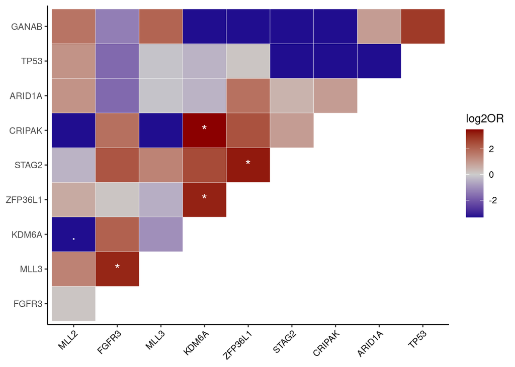

```r
p <- ggplot(res, aes(geneA, geneB)) +
  geom_tile(aes(fill = log2OR),colour = "white") +
  scale_fill_gradient2(low = "darkblue",mid = "grey80",
                       high = "darkred",midpoint=0) +
  geom_text(aes(label=stars), color="white", size=5) +
  theme_classic()+
  theme(axis.text.x = element_text(angle = 45, hjust = 1, colour = "black"),
        axis.title = element_blank())
p
```

```r
ggsave("mutual_exclusivity_multiple_genes.pdf",width = 5,height = 5)
```

# 会话信息